# Prediction of Human Activity

Venkata B Chebolu

February 19, 2019

### SYNOPSIS

This exercise aims to analyze human activity data and predict the manner in which the activity was performed. Six young people performed one set of 10 repetitions of the Unilateral Dumbbell Biceps Curl in five different fashions. The outcome is a factor variable of five levels:

- A : activity was performed according to specification
- B : activity was performed while throwing elbows to front
- C : dumbbell was lifted only half way
- D : dumbbell was lowered only half way
- E : activity was performed while throwing hips to front

We explore Random Forest models for this machine learning exercise. We will choose the smallest number of predictors that will provide good accuracy. We are provided with training and test data, but the outcome is missing from test data, so we split the training data into two parts. We use one part for training the model, and the other for evaluating the model.

### Data Exploration and Clean Up

#### Read files

```r
library(RANN)
library(caret)
library(randomForest)
trn <- read.csv("pml-training.csv")
tst <- read.csv("pml-testing.csv")
set.seed(12321)
```

#### Inspect data for NAs

```r
dim(trn)
```

```
## [1] 19622   160
```

```r
summary(trn)
```

```
##        X            user_name    raw_timestamp_part_1 raw_timestamp_part_2
##  Min.   :    1   adelmo  :3892   Min.   :1.322e+09    Min.   :   294
##  1st Qu.: 4906   carlitos:3112   1st Qu.:1.323e+09    1st Qu.:252912
##  Median : 9812   charles :3536   Median :1.323e+09    Median :496380
##  Mean   : 9812   eurico  :3070   Mean   :1.323e+09    Mean   :500656
##  3rd Qu.:14717   jeremy  :3402   3rd Qu.:1.323e+09    3rd Qu.:751891
##  Max.   :19622   pedro   :2610   Max.   :1.323e+09    Max.   :998801
##
##           cvtd_timestamp  new_window    num_window      roll_belt
##  28/11/2011 14:14: 1498   no :19216   Min.   :  1.0   Min.   :-28.90
##  05/12/2011 11:24: 1497   yes:  406   1st Qu.:222.0   1st Qu.:  1.10
##  30/11/2011 17:11: 1440               Median :424.0   Median :113.00
##  05/12/2011 11:25: 1425               Mean   :430.6   Mean   : 64.41
##  02/12/2011 14:57: 1380               3rd Qu.:644.0   3rd Qu.:123.00
##  02/12/2011 13:34: 1375               Max.   :864.0   Max.   :162.00
##  (Other)         :11007
##    pitch_belt          yaw_belt       total_accel_belt kurtosis_roll_belt
##  Min.   :-55.8000   Min.   :-180.00   Min.   : 0.00             :19216
##  1st Qu.:  1.7600   1st Qu.: -88.30   1st Qu.: 3.00    #DIV/0!  :   10
##  Median :  5.2800   Median : -13.00   Median :17.00    -1.908453:    2
##  Mean   :  0.3053   Mean   : -11.21   Mean   :11.31    -0.016850:    1
##  3rd Qu.: 14.9000   3rd Qu.:  12.90   3rd Qu.:18.00    -0.021024:    1
##  Max.   : 60.3000   Max.   : 179.00   Max.   :29.00    -0.025513:    1
##                                                        (Other)  :  391
##  kurtosis_picth_belt kurtosis_yaw_belt skewness_roll_belt
##           :19216            :19216              :19216
##  #DIV/0!  :   32     #DIV/0!:  406     #DIV/0!  :    9
##  47.000000:    4                       0.000000 :    4
##  -0.150950:    3                       0.422463 :    2
##  -0.684748:    3                       -0.003095:    1
##  -1.750749:    3                       -0.010002:    1
##  (Other)  :  361                       (Other)  :  389
##  skewness_roll_belt.1 skewness_yaw_belt max_roll_belt     max_picth_belt
##           :19216             :19216     Min.   :-94.300   Min.   : 3.00
##  #DIV/0!  :   32      #DIV/0!:  406     1st Qu.:-88.000   1st Qu.: 5.00
##  0.000000 :    4                        Median : -5.100   Median :18.00
##  -2.156553:    3                        Mean   : -6.667   Mean   :12.92
##  -3.072669:    3                        3rd Qu.: 18.500   3rd Qu.:19.00
##  -6.324555:    3                        Max.   :180.000   Max.   :30.00
##  (Other)  :  361                        NA's   :19216     NA's   :19216
```

[output cut: 313 more lines]

```
##  Min.   :-446.00   Min.   :-1280.0   Min.   :-896.0   Min.   :-973.0
##  1st Qu.:-182.00   1st Qu.: -616.0   1st Qu.:   2.0   1st Qu.: 191.0
##  Median : -39.00   Median : -378.0   Median : 591.0   Median : 511.0
##  Mean   : -55.29   Mean   : -312.6   Mean   : 380.1   Mean   : 393.6
##  3rd Qu.:  26.00   3rd Qu.:  -73.0   3rd Qu.: 737.0   3rd Qu.: 653.0
##  Max.   : 291.00   Max.   :  672.0   Max.   :1480.0   Max.   :1090.0
##
##  classe
##  A:5580
##  B:3797
##  C:3422
##  D:3216
##  E:3607
##
##
```

We have NAs in some columns, and some numeric columns don’t seem to have numeric values for most of the rows. We look at NAs first. Let’s get the number of NAs in each column.

```r
sapply(trn, function(x) sum(is.na(x)) )
```

```
##                        X                user_name     raw_timestamp_part_1
##                        0                        0                        0
##     raw_timestamp_part_2           cvtd_timestamp               new_window
##                        0                        0                        0
##               num_window                roll_belt               pitch_belt
##                        0                        0                        0
##                 yaw_belt         total_accel_belt       kurtosis_roll_belt
##                        0                        0                        0
##      kurtosis_picth_belt        kurtosis_yaw_belt       skewness_roll_belt
##                        0                        0                        0
##     skewness_roll_belt.1        skewness_yaw_belt            max_roll_belt
##                        0                        0                    19216
##           max_picth_belt             max_yaw_belt            min_roll_belt
##                    19216                        0                    19216
##           min_pitch_belt             min_yaw_belt      amplitude_roll_belt
##                    19216                        0                    19216
##     amplitude_pitch_belt       amplitude_yaw_belt     var_total_accel_belt
##                    19216                        0                    19216
##            avg_roll_belt         stddev_roll_belt            var_roll_belt
##                    19216                    19216                    19216
##           avg_pitch_belt        stddev_pitch_belt           var_pitch_belt
##                    19216                    19216                    19216
##             avg_yaw_belt          stddev_yaw_belt             var_yaw_belt
##                    19216                    19216                    19216
##             gyros_belt_x             gyros_belt_y             gyros_belt_z
##                        0                        0                        0
##             accel_belt_x             accel_belt_y             accel_belt_z
##                        0                        0                        0
##            magnet_belt_x            magnet_belt_y            magnet_belt_z
##                        0                        0                        0
##                 roll_arm                pitch_arm                  yaw_arm
##                        0                        0                        0
##          total_accel_arm            var_accel_arm             avg_roll_arm
##                        0                    19216                    19216
##          stddev_roll_arm             var_roll_arm            avg_pitch_arm
##                    19216                    19216                    19216
##         stddev_pitch_arm            var_pitch_arm              avg_yaw_arm
##                    19216                    19216                    19216
##           stddev_yaw_arm              var_yaw_arm              gyros_arm_x
##                    19216                    19216                        0
```

[output cut: 53 more lines]

```
##                        0                        0                    19216
##         avg_roll_forearm      stddev_roll_forearm         var_roll_forearm
##                    19216                    19216                    19216
##        avg_pitch_forearm     stddev_pitch_forearm        var_pitch_forearm
##                    19216                    19216                    19216
##          avg_yaw_forearm       stddev_yaw_forearm          var_yaw_forearm
##                    19216                    19216                    19216
##          gyros_forearm_x          gyros_forearm_y          gyros_forearm_z
##                        0                        0                        0
##          accel_forearm_x          accel_forearm_y          accel_forearm_z
##                        0                        0                        0
##         magnet_forearm_x         magnet_forearm_y         magnet_forearm_z
##                        0                        0                        0
##                   classe
##                        0
```

The columns that have NAs have NAs for almost all the rows. Imputing values for them is pointless. It is best to remove them consideration. We keep ‘classe’ out of the column list - we keep the outcome in a separate vector. We also eliminate the column named ‘X’ that seems to be just a row number, and cannot possibly have any influence on the outcome.

```r
goodcols <- names(trn)[ sapply(trn, function(x) sum(is.na(x)) == 0) ]
goodcols <- goodcols[(goodcols != 'classe') & (goodcols != 'X')]
trngood <- trn[,goodcols]
tstgood <- tst[,goodcols]
trny    <- trn$classe
```

#### Eliminate Factor Columns

Then we exclude columns that are supposed to be numeric but are factors because values are missing for most rows. Note that we eliminate the cvtd_timestamp column in this step as it is a factor. We do have two other columns that represent the raw timestamp, so we are losing nothing. Note that the test for column data type is done on training data columns for both assignments below.

```r
trngood <- trngood[,sapply(trngood,class) != "factor"]
tstgood <- tstgood[,sapply(trngood,class) != "factor"]
```

### Model Selection

#### Split Training Data

Data clean up is complete. We split training data into two sets - one for training the model, and one for evaluating the model.

```r
inTrain <- createDataPartition(y=trn$classe, p=0.8, list=F)
trntrn <- trngood[inTrain,]
trneval <- trngood[-inTrain,]
trntrny <- as.factor(trny[inTrain])
trnevaly <- as.factor(trny[-inTrain])
```

As we have a multi-level classification problem on our hands, a model based on decision trees is a candidate for consideration. We will explore a Random Forest classification algorithm, while taking care to keep the model simple in order to avoid overfitting. We choose 200 for the tree count instead of the default 500. We will strive to keep the number of features used in the model small:

- First, we find out how many features are needed for producing a good model. To that end, we run Random Forest Cross-Validation (rfcv) for feature selection on the data. It shows the cross-validated prediction performance of models with sequentially reduced number of features ranked by feature importance.
- Then we run Random Forest algorithm on all available features, and list features in decreasing importance. We select the desired number of features from the top, and re-run the Random Forest algorithm on just those features.

#### Determine Number of Features

```r
res <- rfcv(trainx=trntrn, trainy=trntrny, ntree=200)
res$error.cv
```

```
##           55           28           14            7            3
## 0.0014650615 0.0007643799 0.0007643799 0.0004458883 0.0024842347
##            1
## 0.0084718772
```

We can see that the error rate is pretty good for 7 columns. Next we run random forest on all available features and find out the most important 7 features.

#### Identify Features For Use

```r
ff <- randomForest(x=trntrn, y=trntrny, ntree=200)
cols <- names(importance(ff)[order(-importance(ff)),1])[1:7]
cols
```

```
## [1] "raw_timestamp_part_1" "num_window"           "roll_belt"
## [4] "yaw_belt"             "magnet_dumbbell_z"    "pitch_forearm"
## [7] "pitch_belt"
```

Now that the 7 features are identified, it’s time to prepare the data and re-run random forest on just the 7 features.

#### Create Model

```r
#alltrn <- trngood[,cols]
#alltrn$classe <- trny
#pairs(alltrn)
trntrn <- trntrn[,cols]
trneval <- trneval[,cols]
tstgood <- tstgood[,cols]
ff2 <- randomForest(x=trntrn, y=trntrny, ntree=200)
```

#### Evaluate Model

Let’s see how the model does on training data and evaluation data

```r
confusionMatrix(predict(ff2), trntrny)
```

```
## Confusion Matrix and Statistics
##
##           Reference
## Prediction    A    B    C    D    E
##          A 4464    1    0    0    0
##          B    0 3036    1    0    0
##          C    0    1 2737    0    0
##          D    0    0    0 2573    3
##          E    0    0    0    0 2883
##
## Overall Statistics
##
##                Accuracy : 0.9996
##                  95% CI : (0.9992, 0.9999)
##     No Information Rate : 0.2843
##     P-Value [Acc > NIR] : < 2.2e-16
##
##                   Kappa : 0.9995
##  Mcnemar's Test P-Value : NA
##
## Statistics by Class:
##
##                      Class: A Class: B Class: C Class: D Class: E
## Sensitivity            1.0000   0.9993   0.9996   1.0000   0.9990
## Specificity            0.9999   0.9999   0.9999   0.9998   1.0000
## Pos Pred Value         0.9998   0.9997   0.9996   0.9988   1.0000
## Neg Pred Value         1.0000   0.9998   0.9999   1.0000   0.9998
## Prevalence             0.2843   0.1935   0.1744   0.1639   0.1838
## Detection Rate         0.2843   0.1934   0.1743   0.1639   0.1836
## Detection Prevalence   0.2844   0.1935   0.1744   0.1641   0.1836
## Balanced Accuracy      1.0000   0.9996   0.9998   0.9999   0.9995
```

```r
confusionMatrix(predict(ff2, newdata=trneval), trnevaly)
```

```
## Confusion Matrix and Statistics
##
##           Reference
## Prediction    A    B    C    D    E
##          A 1116    0    0    0    0
##          B    0  759    1    0    0
##          C    0    0  683    0    0
##          D    0    0    0  643    0
##          E    0    0    0    0  721
##
## Overall Statistics
##
##                Accuracy : 0.9997
##                  95% CI : (0.9986, 1)
##     No Information Rate : 0.2845
##     P-Value [Acc > NIR] : < 2.2e-16
##
##                   Kappa : 0.9997
##  Mcnemar's Test P-Value : NA
##
## Statistics by Class:
##
##                      Class: A Class: B Class: C Class: D Class: E
## Sensitivity            1.0000   1.0000   0.9985   1.0000   1.0000
## Specificity            1.0000   0.9997   1.0000   1.0000   1.0000
## Pos Pred Value         1.0000   0.9987   1.0000   1.0000   1.0000
## Neg Pred Value         1.0000   1.0000   0.9997   1.0000   1.0000
## Prevalence             0.2845   0.1935   0.1744   0.1639   0.1838
## Detection Rate         0.2845   0.1935   0.1741   0.1639   0.1838
## Detection Prevalence   0.2845   0.1937   0.1741   0.1639   0.1838
## Balanced Accuracy      1.0000   0.9998   0.9993   1.0000   1.0000
```

The model does better on new data than on training data, which addresses the concerns we had on overfitting.

Let us plot the random forest model.

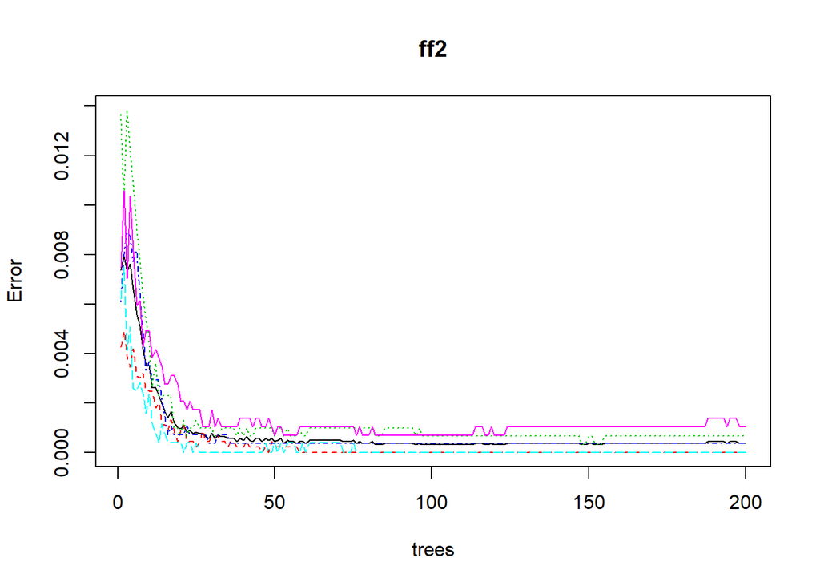

```r
#predict(ff2, tstgood)
plot(ff2)
```

We see that the error rate for all five outcomes goes down as the number of trees goes up.